# Assignment-5

RUTHRESHWARAN M

2023-05-04

```r
library(ggplot2)
library(haven)
datatibble1 <- read_sav("Raw/chap6data.sav")
datatibble1
```

```
## # A tibble: 2,680 × 9
##    hraisedp  astatus1        owner    mrelate rerelate cvariety cdiscret control
##    <dbl+lbl> <dbl+lbl>       <dbl+lb> <dbl+l> <dbl+lb> <dbl+lb> <dbl+lb> <dbl+l>
##  1 NA         8 [government… NA       1 [ver… 5 [very…  4 [a l… 3 [some] 3 [som…
##  2 NA        12 [local/cent…  4 [pub… 1 [ver… 5 [very…  4 [a l… 3 [some] 3 [som…
##  3 NA         5 [trust / ch…  3 [tru… 2 [goo… 4 [good]  4 [a l… 3 [some] 3 [som…
##  4 NA         2 [private li…  2 [pri… 2 [goo… 4 [good]  3 [som… 3 [some] 2 [a l…
##  5  3         2 [private li…  2 [pri… 2 [goo… 4 [good]  2 [a l… 1 [none] 1 [non…
##  6 NA         1 [public lim…  1 [pub… 1 [ver… 5 [very…  4 [a l… 3 [some] 3 [som…
##  7 NA         1 [public lim…  1 [pub… 2 [goo… 4 [good]  2 [a l… 4 [a lo… 3 [som…
##  8 NA        12 [local/cent…  4 [pub… 2 [goo… 4 [good] NA       3 [some] 2 [a l…
##  9 NA        12 [local/cent…  4 [pub… 2 [goo… 4 [good]  4 [a l… 4 [a lo… 4 [a l…
## 10 NA         1 [public lim…  1 [pub… 2 [goo… 4 [good]  3 [som… 4 [a lo… 4 [a l…
## # ℹ 2,670 more rows
## # ℹ 1 more variable: cdesign <dbl+lbl>
```

```r
datatibble1$owner
```

[output not shown]

[output cut: 106 more lines]

```r
datatibble1$rerelate
```

[output not shown]

[output cut: 107 more lines]

```r
freq_table <- table(datatibble1$owner)
freq_table
```

```
##
##   1   2   3   4
## 434 978 214 654
```

```r
prop.table(freq_table)
```

```
##
##          1          2          3          4
## 0.19035088 0.42894737 0.09385965 0.28684211
```

```r
summary(datatibble1$owner)
```

```
##    Min. 1st Qu.  Median    Mean 3rd Qu.    Max.    NA's
##   1.000   2.000   2.000   2.477   4.000   4.000     400
```

```r
library(psych)
describe(datatibble1$owner)
```

```
##    vars    n mean  sd median trimmed  mad min max range skew kurtosis   se
## X1    1 2280 2.48 1.1      2    2.48 1.48   1   4     3 0.28    -1.29 0.02
```

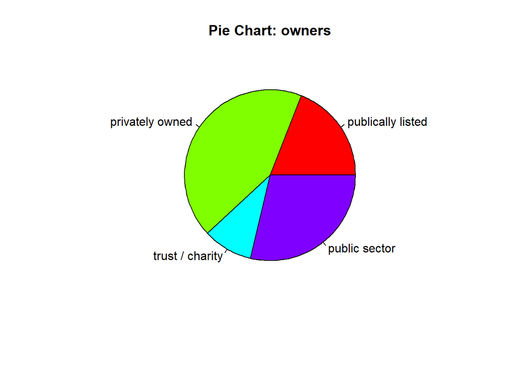

```r
label1 <- c("publically listed","privately owned","trust / charity","public sector")

pie(freq_table, label1, main="Pie Chart: owners",col = rainbow(length(freq_table)))
```

Dependent Variable: rerelate

```r
freq_table1 <- table(datatibble1$rerelate)
freq_table1
```

```
##
##    1    2    3    4    5
##    4   42  218 1407 1001
```

```r
summary(datatibble1$rerelate)
```

```
##    Min. 1st Qu.  Median    Mean 3rd Qu.    Max.    NA's
##   1.000   4.000   4.000   4.257   5.000   5.000       8
```

```r
describe(datatibble1$rerelate)
```

```
##    vars    n mean   sd median trimmed mad min max range  skew kurtosis   se
## X1    1 2672 4.26 0.68      4    4.26   0   1   5     4 -0.78     1.12 0.01
```

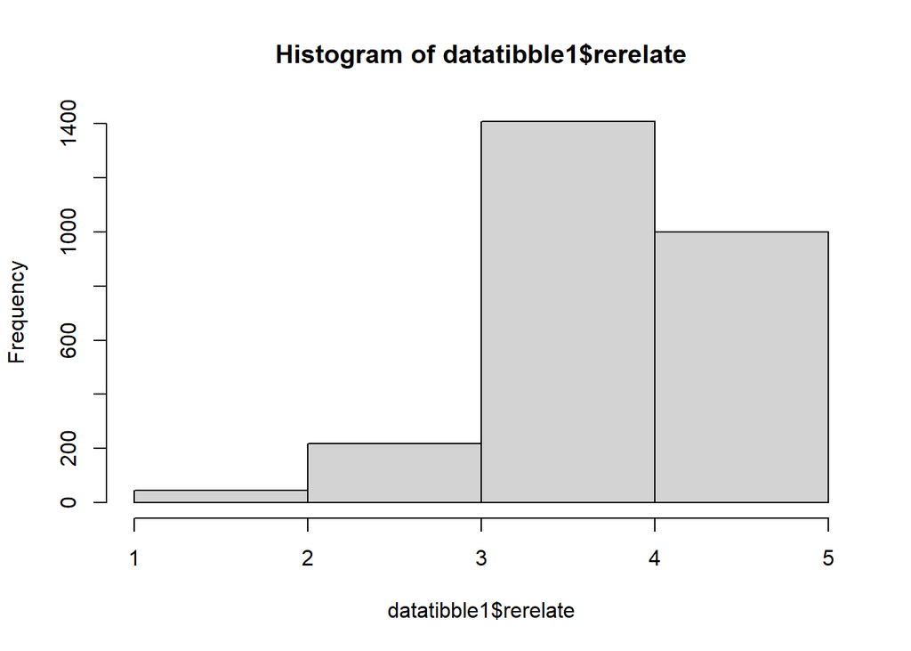

```r
hist(datatibble1$rerelate, breaks = 5)
```

One-Way ANOVA:

```r
org_aov <- aov(datatibble1$rerelate ~ factor(datatibble1$owner))

org_aov
```

```
## Call:
##    aov(formula = datatibble1$rerelate ~ factor(datatibble1$owner))
##
## Terms:
##                 factor(datatibble1$owner) Residuals
## Sum of Squares                    17.5578 1021.1845
## Deg. of Freedom                         3      2270
##
## Residual standard error: 0.6707168
## Estimated effects may be unbalanced
## 406 observations deleted due to missingness
```

```r
summary(org_aov)
```

```
##                             Df Sum Sq Mean Sq F value Pr(>F)
## factor(datatibble1$owner)    3   17.6   5.853   13.01  2e-08 ***
## Residuals                 2270 1021.2   0.450
## ---
## Signif. codes:  0 '***' 0.001 '**' 0.01 '*' 0.05 '.' 0.1 ' ' 1
## 406 observations deleted due to missingness
```

```r
library(car)
leveneTest(datatibble1$rerelate ~ factor(datatibble1$owner),centre = mean)
```

```
## Levene's Test for Homogeneity of Variance (center = median: mean)
##         Df F value Pr(>F)
## group    3  1.3964  0.242
##       2270
```

Effect Size:

```r
library(sjstats)
effectsize::eta_squared(org_aov, partial = TRUE)
```

```
## For one-way between subjects designs, partial eta squared is equivalent
##   to eta squared. Returning eta squared.
```

```
## # Effect Size for ANOVA
##
## Parameter                 | Eta2 |       95% CI
## -----------------------------------------------
## factor(datatibble1$owner) | 0.02 | [0.01, 1.00]
##
## - One-sided CIs: upper bound fixed at [1.00].
```

```r
library(effectsize)
Aov <- oneway.test(owner ~ rerelate, data = datatibble1, var.equal = TRUE)
effectsize(Aov)
```

```
## Eta2 |       95% CI
## -------------------
## 0.02 | [0.01, 1.00]
##
## - One-sided CIs: upper bound fixed at [1.00].
```

```r
effectsize(org_aov)
```

```
## For one-way between subjects designs, partial eta squared is equivalent
##   to eta squared. Returning eta squared.
```

```
## # Effect Size for ANOVA
##
## Parameter                 | Eta2 |       95% CI
## -----------------------------------------------
## factor(datatibble1$owner) | 0.02 | [0.01, 1.00]
##
## - One-sided CIs: upper bound fixed at [1.00].
```

```r
effectsize(org_aov, partial = TRUE)
```

```
## For one-way between subjects designs, partial eta squared is equivalent
##   to eta squared. Returning eta squared.
```

```
## # Effect Size for ANOVA
##
## Parameter                 | Eta2 |       95% CI
## -----------------------------------------------
## factor(datatibble1$owner) | 0.02 | [0.01, 1.00]
##
## - One-sided CIs: upper bound fixed at [1.00].
```

```r
effectsize(org_aov, partial = FALSE)
```

```
## # Effect Size for ANOVA (Type I)
##
## Parameter                 | Eta2 |       95% CI
## -----------------------------------------------
## factor(datatibble1$owner) | 0.02 | [0.01, 1.00]
##
## - One-sided CIs: upper bound fixed at [1.00].
```

```r
library(afex)
eta_squared(org_aov)
```

```
## For one-way between subjects designs, partial eta squared is equivalent
##   to eta squared. Returning eta squared.
```

```
## # Effect Size for ANOVA
##
## Parameter                 | Eta2 |       95% CI
## -----------------------------------------------
## factor(datatibble1$owner) | 0.02 | [0.01, 1.00]
##
## - One-sided CIs: upper bound fixed at [1.00].
```

```r
omega_squared(org_aov)
```

```
## For one-way between subjects designs, partial omega squared is
##   equivalent to omega squared. Returning omega squared.
```

```
## # Effect Size for ANOVA
##
## Parameter                 | Omega2 |       95% CI
## -------------------------------------------------
## factor(datatibble1$owner) |   0.02 | [0.01, 1.00]
##
## - One-sided CIs: upper bound fixed at [1.00].
```

Post-hoc Test:

```r
TukeyHSD(org_aov)
```

```
##   Tukey multiple comparisons of means
##     95% family-wise confidence level
##
## Fit: aov(formula = datatibble1$rerelate ~ factor(datatibble1$owner))
##
## $`factor(datatibble1$owner)`
##            diff         lwr         upr     p adj
## 2-1  0.04693197 -0.05254023  0.14640417 0.6186258
## 3-1 -0.06595891 -0.20999327  0.07807545 0.6412662
## 4-1 -0.16087849 -0.26780302 -0.05395395 0.0006512
## 3-2 -0.11289088 -0.24303725  0.01725549 0.1154512
## 4-2 -0.20781046 -0.29513192 -0.12048900 0.0000000
## 4-3 -0.09491957 -0.23084682  0.04100767 0.2757952
```

Exploring the variable “Variety”:

```r
summary(datatibble1$cvariety)
```

```
##    Min. 1st Qu.  Median    Mean 3rd Qu.    Max.    NA's
##   1.000   3.000   3.000   3.312   4.000   4.000       6
```

```r
describe(datatibble1$cvariety)
```

```
##    vars    n mean   sd median trimmed  mad min max range  skew kurtosis   se
## X1    1 2674 3.31 0.76      3    3.31 1.48   1   4     3 -0.85     0.03 0.01
```

```r
freq_table1 <- table(datatibble1$cvariety)
freq_table1
```

```
##
##    1    2    3    4
##   50  338 1013 1273
```

```r
cumsum(freq_table1)
```

```
##    1    2    3    4
##   50  388 1401 2674
```

```r
prop.table(freq_table1)
```

```
##
##          1          2          3          4
## 0.01869858 0.12640239 0.37883321 0.47606582
```

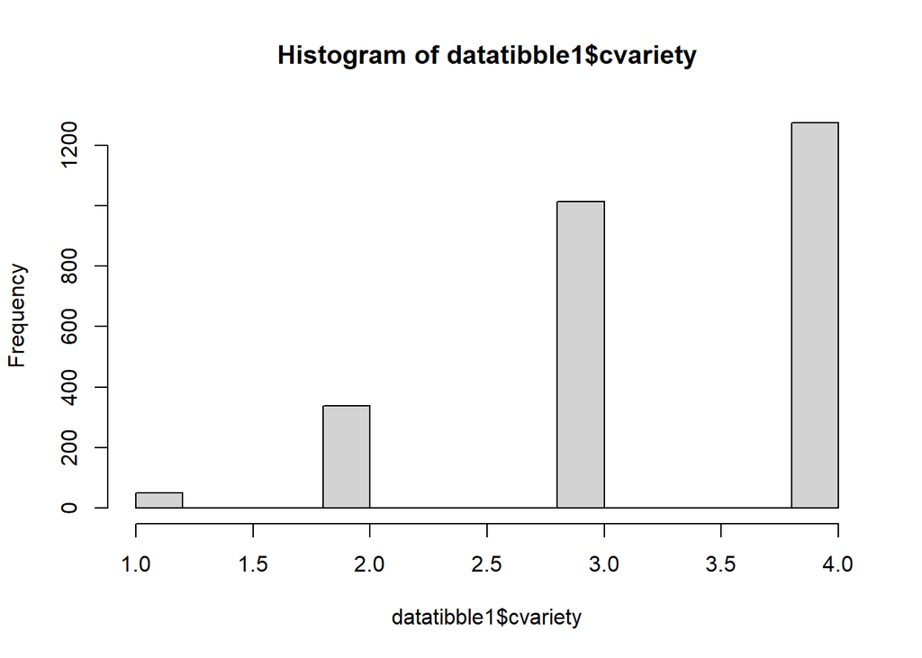

```r
hist(datatibble1$cvariety)
```

```r
org_aov1 <-aov(cvariety ~ factor(owner), data = datatibble1)

summary(org_aov1)
```

```
##                 Df Sum Sq Mean Sq F value   Pr(>F)
## factor(owner)    3   29.6   9.854   17.75 2.19e-11 ***
## Residuals     2271 1260.9   0.555
## ---
## Signif. codes:  0 '***' 0.001 '**' 0.01 '*' 0.05 '.' 0.1 ' ' 1
## 405 observations deleted due to missingness
```

```r
leveneTest(cvariety ~ factor(owner), data = datatibble1, center = mean)
```

```
## Levene's Test for Homogeneity of Variance (center = mean)
##         Df F value Pr(>F)
## group    3  1.8406 0.1377
##       2271
```

```r
eta_squared(org_aov1)
```

```
## For one-way between subjects designs, partial eta squared is equivalent
##   to eta squared. Returning eta squared.
```

```
## # Effect Size for ANOVA
##
## Parameter     | Eta2 |       95% CI
## -----------------------------------
## factor(owner) | 0.02 | [0.01, 1.00]
##
## - One-sided CIs: upper bound fixed at [1.00].
```

```r
omega_squared(org_aov1)
```

```
## For one-way between subjects designs, partial omega squared is
##   equivalent to omega squared. Returning omega squared.
```

```
## # Effect Size for ANOVA
##
## Parameter     | Omega2 |       95% CI
## -------------------------------------
## factor(owner) |   0.02 | [0.01, 1.00]
##
## - One-sided CIs: upper bound fixed at [1.00].
```

Post-hoc Test:

```r
library(dplyr)
```

```r
library(ggplot2)

result <- TukeyHSD(org_aov1)
df <- as.data.frame(datatibble1)
```

[output not shown]

Repeated Measures Analysis of Variance using R:

It is similar to paired sample t-Test. One-Way ANOVA involves two variables, one a nominal multi-category variable and the other an ordinal or scale level variable; A Repeated measures ANOVA involves three or more variables, all ordinal or scale level in measurement.

Thus, Instead of breaking one ordinal or scale level dependent variable into independent groups (as in one way ANOVA), a repeated measures ANOVA makes comparisons across multiple ordinal or scale level variables answered sequentially (hence the term repeated measures).

Example: Imagine that you are doing some marketing research to find out how the emotional expressions of service sector staff affect consumer spending. Specifically you wonder whether different emotions expressed by service sector staff are associated with different levels of spending.

You hypothesize that the service sector staff with a visible smile will result in higher levels of consumption then service sector staff with a neutral expression, and that both the smile and neutral expression will result in higher levels of consumer spending than service sector staff with an angry facial expression.

Data Collection: To test this hypothesis, you take photographs of a young woman with three different facial expressions: smiling, neutral, and angry. Let us say that you showed these three photographs to 185 consumers and asked them to approximate how much they would spend in a retail outlet when being served by these three employees. The resultant data set is given as c6repeatedm. All 185 respondents looked at the three photos and indicated how much money (in US dollars) they would spend in each store at which the young woman is assumed to work.

Thus, in our repeated measures ANOVA, we have three scale-level variables that report consumer spending across the three emotional expressions. To find out whether the mean scores are different across these three variables, we will need to run a one-way repeated measures ANOVA.

```r
datatibble2 <- read_sav("Raw/c6repeatedm.sav")
datatibble2
```

```
## # A tibble: 185 × 3
##    Fsmile Fneutral Fangry
##     <dbl>    <dbl>  <dbl>
##  1     20        2      1
##  2     20        8      4
##  3     25       20     15
##  4     25       20     10
##  5     25       20      5
##  6     25        7      1
##  7     20        5      1
##  8     25        5      1
##  9     25       10      1
## 10     25       20      1
## # ℹ 175 more rows
```

```r
summary(datatibble2)
```

```
##      Fsmile        Fneutral        Fangry
##  Min.   : 1.0   Min.   : 1.0   Min.   : 1.000
##  1st Qu.:20.0   1st Qu.: 3.0   1st Qu.: 1.000
##  Median :25.0   Median :10.0   Median : 1.000
##  Mean   :21.4   Mean   :10.9   Mean   : 4.259
##  3rd Qu.:25.0   3rd Qu.:20.0   3rd Qu.: 4.000
##  Max.   :25.0   Max.   :25.0   Max.   :25.000
```

```r
describe(datatibble2)
```

```
##          vars   n  mean   sd median trimmed   mad min max range  skew kurtosis
## Fsmile      1 185 21.40 6.73     25   23.04  0.00   1  25    24 -1.83     2.03
## Fneutral    2 185 10.90 8.63     10   10.40 11.86   1  25    24  0.45    -1.25
## Fangry      3 185  4.26 7.05      1    2.25  0.00   1  25    24  2.27     3.75
##            se
## Fsmile   0.49
## Fneutral 0.63
## Fangry   0.52
```

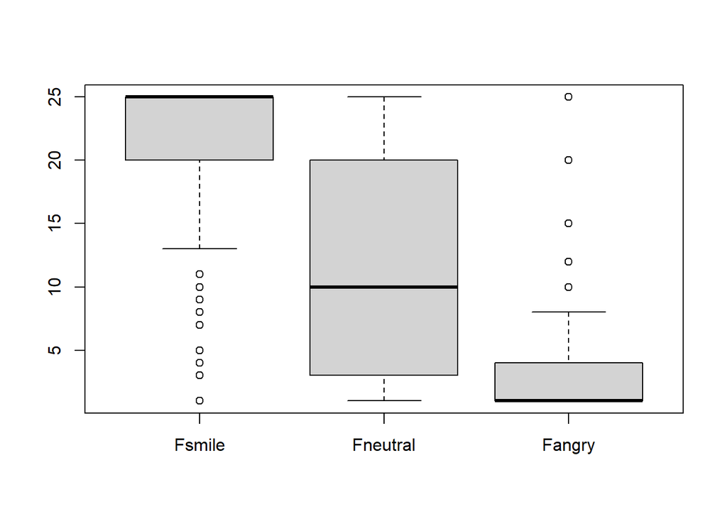

```r
boxplot(datatibble2)
```

Preparing Data:

```r
df1 <- data.frame(Con_Spending = datatibble2$Fsmile, Emotion = rep("Smile", times = 185))
df1
```

```
##     Con_Spending Emotion
## 1             20   Smile
## 2             20   Smile
## 3             25   Smile
## 4             25   Smile
## 5             25   Smile
## 6             25   Smile
## 7             20   Smile
## 8             25   Smile
## 9             25   Smile
## 10            25   Smile
## 11            25   Smile
## 12            25   Smile
## 13            15   Smile
## 14            25   Smile
```

[output cut: 171 more lines]

```r
df2 <- data.frame(Con_Spending = datatibble2$Fneutral, Emotion = rep("Neutral", times = 185))
df2
```

```
##     Con_Spending Emotion
## 1              2 Neutral
## 2              8 Neutral
## 3             20 Neutral
## 4             20 Neutral
## 5             20 Neutral
## 6              7 Neutral
## 7              5 Neutral
## 8              5 Neutral
## 9             10 Neutral
## 10            20 Neutral
## 11             1 Neutral
## 12            20 Neutral
## 13             2 Neutral
## 14             1 Neutral
```

[output cut: 171 more lines]

```r
df3 <- data.frame(Con_Spending = datatibble2$Fangry, Emotion = rep("Angry", times = 185))
df3
```

```
##     Con_Spending Emotion
## 1              1   Angry
## 2              4   Angry
## 3             15   Angry
## 4             10   Angry
## 5              5   Angry
## 6              1   Angry
## 7              1   Angry
## 8              1   Angry
## 9              1   Angry
## 10             1   Angry
## 11             1   Angry
## 12            15   Angry
## 13             1   Angry
## 14             1   Angry
```

[output cut: 171 more lines]

```r
df1 <- rbind(df1,df2)
df1 <- rbind(df1,df3)
df1
```

```
##     Con_Spending Emotion
## 1             20   Smile
## 2             20   Smile
## 3             25   Smile
## 4             25   Smile
## 5             25   Smile
## 6             25   Smile
## 7             20   Smile
## 8             25   Smile
## 9             25   Smile
## 10            25   Smile
## 11            25   Smile
## 12            25   Smile
## 13            15   Smile
## 14            25   Smile
```

[output cut: 541 more lines]

```r
library(tidyverse)
library(rstatix)
```

```r
library(ggplot2)
library(ggpubr)


df1 %>%
  group_by(Emotion) %>%
  get_summary_stats(Con_Spending, type="mean_sd")
```

```
## # A tibble: 3 × 5
##   Emotion variable         n  mean    sd
##   <chr>   <fct>        <dbl> <dbl> <dbl>
## 1 Angry   Con_Spending   185  4.26  7.04
## 2 Neutral Con_Spending   185 10.9   8.63
## 3 Smile   Con_Spending   185 21.4   6.73
```

Other Way:

```r
df_new <- as.data.frame(datatibble2)
df_new$id <- 1:185
df_new
```

```
##     Fsmile Fneutral Fangry  id
## 1       20        2      1   1
## 2       20        8      4   2
## 3       25       20     15   3
## 4       25       20     10   4
## 5       25       20      5   5
## 6       25        7      1   6
## 7       20        5      1   7
## 8       25        5      1   8
## 9       25       10      1   9
## 10      25       20      1  10
## 11      25        1      1  11
## 12      25       20     15  12
## 13      15        2      1  13
## 14      25        1      1  14
```

[output cut: 171 more lines]

```r
df_new <- df_new %>%
  gather(key = "Emotion", value = "Con_Spending", Fsmile, Fneutral, Fangry) %>%
  convert_as_factor(id, Emotion)
df_new
```

```
##      id  Emotion Con_Spending
## 1     1   Fsmile           20
## 2     2   Fsmile           20
## 3     3   Fsmile           25
## 4     4   Fsmile           25
## 5     5   Fsmile           25
## 6     6   Fsmile           25
## 7     7   Fsmile           20
## 8     8   Fsmile           25
## 9     9   Fsmile           25
## 10   10   Fsmile           25
## 11   11   Fsmile           25
## 12   12   Fsmile           25
## 13   13   Fsmile           15
## 14   14   Fsmile           25
```

[output cut: 541 more lines]

Visualize the data

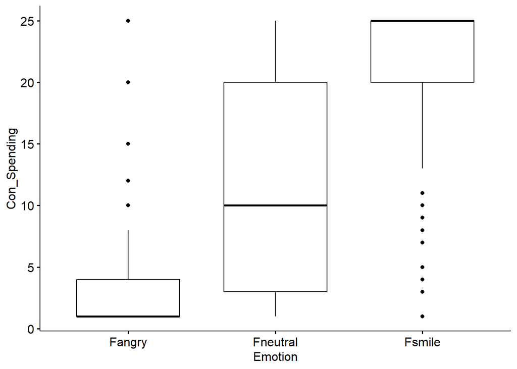

```r
g_out <- ggboxplot(df_new, x = "Emotion", y = "Con_Spending")
g_out
```

Identify Outliers

```r
df_new %>%
  group_by(Emotion) %>%
  identify_outliers(Con_Spending)
```

```
## # A tibble: 53 × 5
##    Emotion id    Con_Spending is.outlier is.extreme
##    <fct>   <fct>        <dbl> <lgl>      <lgl>
##  1 Fangry  3               15 TRUE       TRUE
##  2 Fangry  4               10 TRUE       FALSE
##  3 Fangry  12              15 TRUE       TRUE
##  4 Fangry  19              25 TRUE       TRUE
##  5 Fangry  26              25 TRUE       TRUE
##  6 Fangry  27              25 TRUE       TRUE
##  7 Fangry  40              25 TRUE       TRUE
##  8 Fangry  41              25 TRUE       TRUE
##  9 Fangry  43              25 TRUE       TRUE
## 10 Fangry  45              25 TRUE       TRUE
## # ℹ 43 more rows
```

Normality Assumption

```r
df_new %>%
  group_by(Emotion) %>%
  shapiro_test(Con_Spending)
```

```
## # A tibble: 3 × 4
##   Emotion  variable     statistic        p
##   <fct>    <chr>            <dbl>    <dbl>
## 1 Fangry   Con_Spending     0.512 2.00e-22
## 2 Fneutral Con_Spending     0.865 9.03e-12
## 3 Fsmile   Con_Spending     0.597 1.29e-20
```

Repeated Measures ANOVA:

```r
res.aov <- anova_test(data = df_new, dv = Con_Spending, wid = id, within = Emotion)
get_anova_table(res.aov)
```

```
## ANOVA Table (type III tests)
##
##    Effect  DFn    DFd       F        p p<.05  ges
## 1 Emotion 1.92 353.91 434.702 5.18e-94     * 0.47
```

Post-hoc Test:

```r
post_tst <- df_new %>%
  pairwise_t_test(
    Con_Spending ~ Emotion, paired = TRUE,
    p.adjust.method = "bonferroni"
    )
post_tst
```

```
## # A tibble: 3 × 10
##   .y.   group1 group2    n1    n2 statistic    df        p    p.adj p.adj.signif
## * <chr> <chr>  <chr>  <int> <int>     <dbl> <dbl>    <dbl>    <dbl> <chr>
## 1 Con_… Fangry Fneut…   185   185     -12.4   184 4.20e-26 1.26e-25 ****
## 2 Con_… Fangry Fsmile   185   185     -26.9   184 9.23e-66 2.77e-65 ****
## 3 Con_… Fneut… Fsmile   185   185     -18.0   184 1.80e-42 5.40e-42 ****
```

Conclusion:

We have learnt to carry out bivariate ANOVA tests in two different forms. The one-way ANOVA compares a set of mean scores across multiple categories of the independent variable. The repeated measures ANOVA compares a set of mean scores across multiple variables measured sequentially. Both tests tell us whether the mean scores we are comparing are significantly different from one another and, if so, where they are different.